# kubo7

# GLMでは説明できないカウントデータ

- 現実のデータのばらつきは, ポアソン分布や二項分布だけではうまく説明できない
  - データにばらつきをもたらす「原因不明な(人間が測定できない・測定しなかった)個体差」がある
  - => **GLMM**
- **一般化線形混合モデル(generalized linear mixed model, GLMM)**: 「測定できない・しなかった個体差」を組み込んだGLM
  - **複数の確率分布を部品とする統計モデル**
    - e.g.) データのばらつきは二項分布、個体のばらつきは正規分布で表す

[figure not shown]

GLMの拡張

Example data

- 生存種子数が葉数とともにどのように増大するかを調べる
  - $y_{i} \leq 8$: $i$ の生存種子数
  - $2 \leq x_{i} \leq 6$: $i$ の葉数
  - $x_{i}$ の値ごとに20個体ずつサンプル, 全部で100個体をサンプル

```r
# only the first 25 rows gonna be rendered (5 rows per page)
d <- read.csv('/Users/hamaokigaizaburo/Documents/kuboR/intro-statistical-modeling-master/data/data7.csv')
d
```

```
    N y x  id
1   8 0 2   1
2   8 1 2   2
3   8 2 2   3
4   8 4 2   4
5   8 1 2   5
6   8 0 2   6
7   8 0 2   7
8   8 7 2   8
9   8 1 2   9
10  8 6 2  10
11  8 0 2  11
12  8 0 2  12
13  8 0 2  13
14  8 0 2  14
```

[output cut: 86 more lines]

```r
summary(d)
```

```
       N           y              x           id
 Min.   :8   Min.   :0.00   Min.   :2   Min.   :  1.00
 1st Qu.:8   1st Qu.:1.00   1st Qu.:3   1st Qu.: 25.75
 Median :8   Median :3.00   Median :4   Median : 50.50
 Mean   :8   Mean   :3.81   Mean   :4   Mean   : 50.50
 3rd Qu.:8   3rd Qu.:7.00   3rd Qu.:5   3rd Qu.: 75.25
 Max.   :8   Max.   :8.00   Max.   :6   Max.   :100.00
```

以下の破線が真の生存確率.

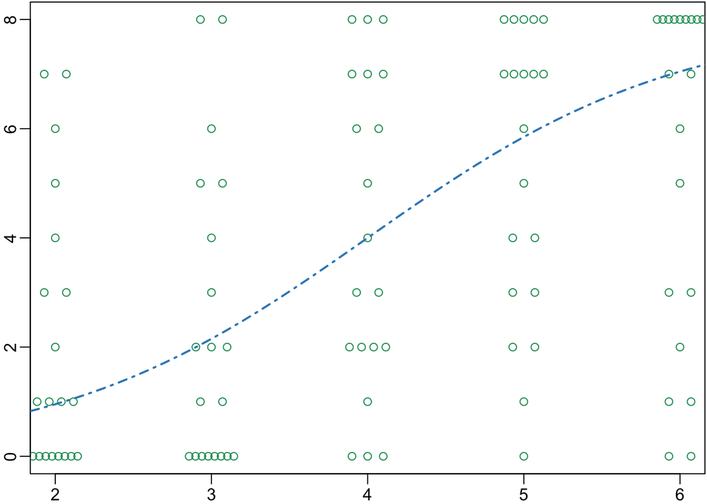

```r
v.x <- 0:8
xx <- seq(1, 7, 0.1)

logistic <- function(z) 1 / (1 + exp(-z))

plot.d <- function(
                   d, w = 0.1, col = "#199a60",
                   xlab = "x", ylab = "y",
                   axes = TRUE,
                   ylim = range(d$y),
                   ...) {
    plot(
        d$x, d$y,
        type = "n", # no plot
        xlab = xlab, ylab = ylab,
        axes = axes,
        ylim = ylim
    )
    for (x in sort(unique(d$x))) {
        dsub <- d[d$x == x, ]
        for (ns in sort(unique(dsub$y))) {
            n <- sum(dsub$y == ns)
            sx <- 1:n
            sdx <- ifelse(n == 1, 1, sd(sx))
            points(
                x + (sx - mean(sx)) / sdx * w,
                rep(ns, n),
                col = col,
                ...
            )
        }
    }
}

par.glmm <- function() par(mar = c(1.5, 1.5, 0.1, 0.1), mgp = c(1.5, 0.5, 0), cex = 1.0)
col.true = "#398ac2"
line.true <- function(col = col.true) lines(xx, logistic(-4 + 1 * xx) * max(v.x), lwd = 2, lty = 4, col = col)

par.glmm()
plot.d(d)
line.true()
```

まず, ロジットリンク関数を用いたGLMでモデリングを行うと以下のような結果になる.

$${\rm logit}(q_{i}) = \beta_{1} + \beta_{2} x_{i} \\
p(y_{i} | \beta_{1}, \beta_{2}, x_{i}) = \Biggl( \begin{matrix}8 \\ y\end{matrix} \Biggr) q_{i}^{y_{i}} (1 - q_{i})^{8 - y_{i}} \\
{\rm log} L = \sum_{i} {\rm log} p(y_{i} | \beta_{1}, \beta_{2})$$

```r
fit.glm <- glm(cbind(y, N - y) ~ x, family = binomial, data = d)
beta.glm <- fit.glm$coefficients
```

- 切片 ${\hat \beta_{1}}$ : -2.1487448
- 傾き ${{\hat \beta_{2}}}$ : 0.5103806

推定結果に基づく図示が以下.

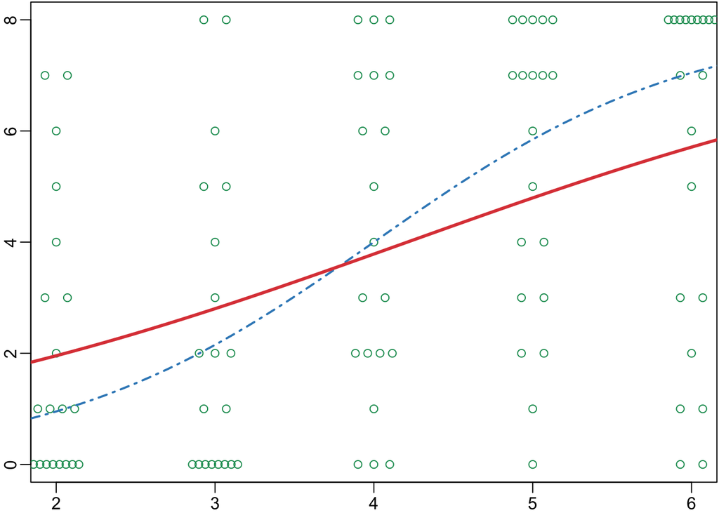

```r
col.glm <- "#de4545"

par.glmm()
plot.d(d)
line.true()
lines(xx, logistic(beta.glm[1] + beta.glm[2] * xx) * max(v.x), lwd = 3, col = col.glm)
```

真の傾き $\beta_{2} = 1$ に対して, かなり小さな値が推定されてしまっている.

# 過分散と個体差

- $x_{i} = 4$ だった場合の生存種子数と, 推定されたモデルの予測を比較する.
  - 予測生存確率 $q_{i}$ : logistic(-2.1487448 + 0.5103806 * 4) = 0.47322

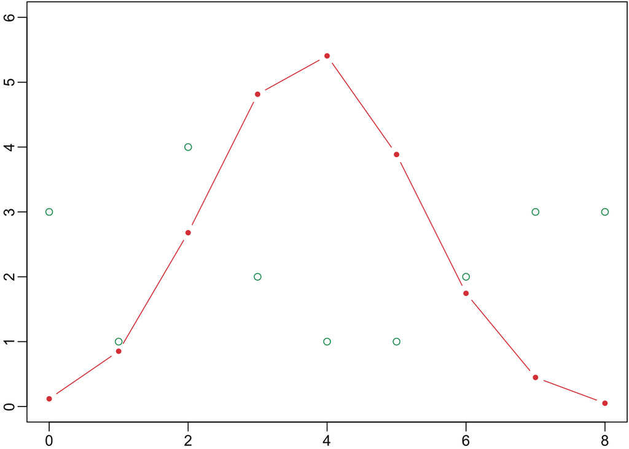

```r
par.glmm()
d4 <- d[d$x == 4,]
prob <- logistic(beta.glm[1] + beta.glm[2] * 4)
plot(
    v.x, dbinom(v.x, 8, prob = prob) * nrow(d4),
    type = "b",
    ylim = c(0, 6),
    pch = 20, col = col.glm,
    xlab = "x", ylab = "y"
)
points(v.x, summary(factor(d4$y, levels = v.x)), pch = 1, col = "#199a60")
```

- データは明らかに二項分布に従っていない
  - => **過分散(過大分散, overdispersion)**: 二項分布で期待されるよりも大きなばらつきが生じている
    - c.f.) **過小分散(underdispersion)**: 期待される分散よりも標本分散がかなり小さくなること

## 過分散

$x_{i} = 4$ の個体の, 平均および分散は以下のようになる.

```r
c(mean(d4$y), var(d4$y))
```

```
[1] 4.050000 8.365789
```

- 生存確率の平均が $4.05 / 8 = 0.5$ ぐらいなら, もし生存種子数 $y_{i}$ が二項分布に従うならば, その分散は, $8 \times 0.5 \times (1 - 0.5) = 2$ ぐらいになるはず
  - [c.f.](https://mathtrain.jp/bin) ) 二項分布 $X \sim B(n, p)$ としたとき
    - 期待値 $E(X) = np$
    - 分散 $V(X) = np(1 - p)$
- しかし, 実際の分散は 8.3657895 であり, 4倍ほど大きい: 二項分布における過分散の例
  - c.f. ) ポアソン分布も過分散が生じる
    - ポアソン分布: 平均と分散が等しい確率分布
    - but ) 実際のカウントデータでは, 平均よりも分散のほうが大きくなる場合がほとんど

## 観測されていない個体差

- 極端な個体差があるとして, 全個体の半数の生存種子数が8, 残りの半数が0とした場合, 過分散はよりひどくなる
  - 平均: $(8 \times 4 + 0 \times 4) / 8 = 4$
  - 分散: $8 \times 4^2 / 8 = 16$
  - 二項分布から期待される分散: $Nq(1 - q) = 8 \times 0.5 \times 0.5 = 2$
- -> *個体差があれば過分散が生じうる*
  - 「個体たちはみんな均質」といった過度に単純化した仮定を設けて, 「全個体の生存種子数の分布は, ただひとつの二項分布で説明できる」としてしまった
- 観測者が観測対象に影響を与えている要因すべてを定量・特定することはどうやっても不可能
  - => 個体差や場所差を原因不明ののまま, これらの及ぼす影響を統計モデルにうまく取り込む必要がある: 一般化線形混合モデル, GLMM

# 一般化線形混合モデル

## 個体差を表すパラメータの追加

個体差を表すパラメータ $r_{i}$ を $q_{i}$ に追加.

$${\rm logit} (q_{i}) = \beta_{1} + \beta_{2} x_{i} + r_{i}$$

- $q_{i} \in (- \infty, \infty)$ : 連続値
  - GLMは $q_{i} = 0$ としていることに相当する

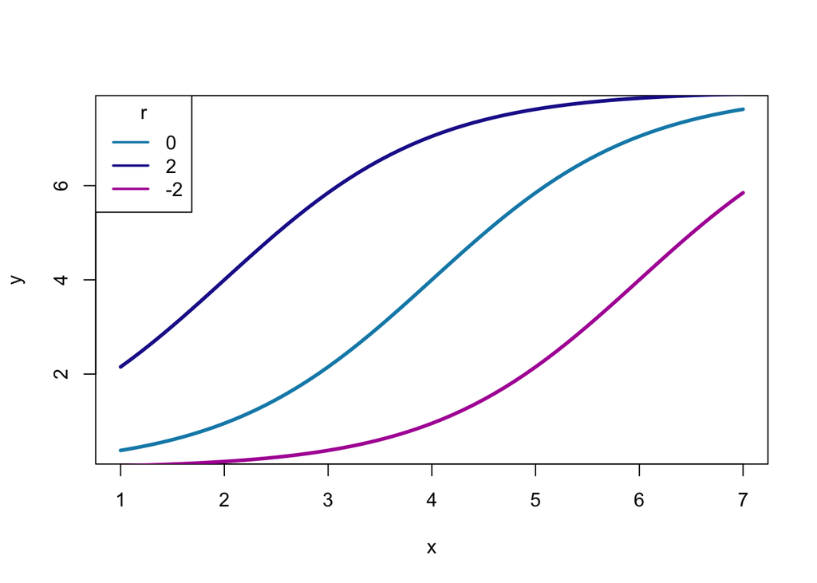

```r
cols <- c("#118ab6", "#212198", "#af13a4")
plot(xx, logistic(-4 + 1 * xx + 0) * max(v.x), type = "l", xlab = "x", ylab = "y", col = cols[1], lwd = 3)
lines(xx, logistic(-4 + 1 * xx + 2) * max(v.x), col = cols[2], lwd = 3)
lines(xx, logistic(-4 + 1 * xx + -2) * max(v.x), col = cols[3], lwd = 3)
legend("topleft", legend = c(0, 2, -2), col = cols, lwd = 2, title = "r")
```

## 個体差のばらつきを表す確率分布

- GLMM: 個体差をあらわすパラメータ ${r_{1}, r_{2}, ..., r_{100}}$ が何かの確率分布に従っていると仮定
  - データに基づいてその確率分布のパラメータを推定できると考える
- ここでは, $r_{i}$ が平均 $\mu = 0$ で, 標準偏差 $s$ の (相互に独立した) *正規分布* に従うと仮定する
  - **なぜ正規分布なのか??**
    - そもそも, $r_{i}$ は観測できない・しなかった量なので, どのような確率分布に従うかはわからない
    - 正規分布を使う理由: 単にこのような統計モデリングに便利だから
  - c.f. )
    - 異常値の多い集団を扱うときは, $r_{i}$ がもっと「すその重い」確率分布に従うと仮定する: $t$ 分布
    - 階層ベイズモデル: $r_{i}$ の分布にさまざまなばらつきの正規分布を混合したものを使う

$r_{i}$ の確率密度分布は以下のようになり, $s$ を変化させたとき分布のプロットは次のようになる.
$$p(r_{i} | s) = \frac{1}{\sqrt{2 \pi s^2}} \exp \biggl( - \frac{r_{i}^2}{2s^2} \biggr)$$

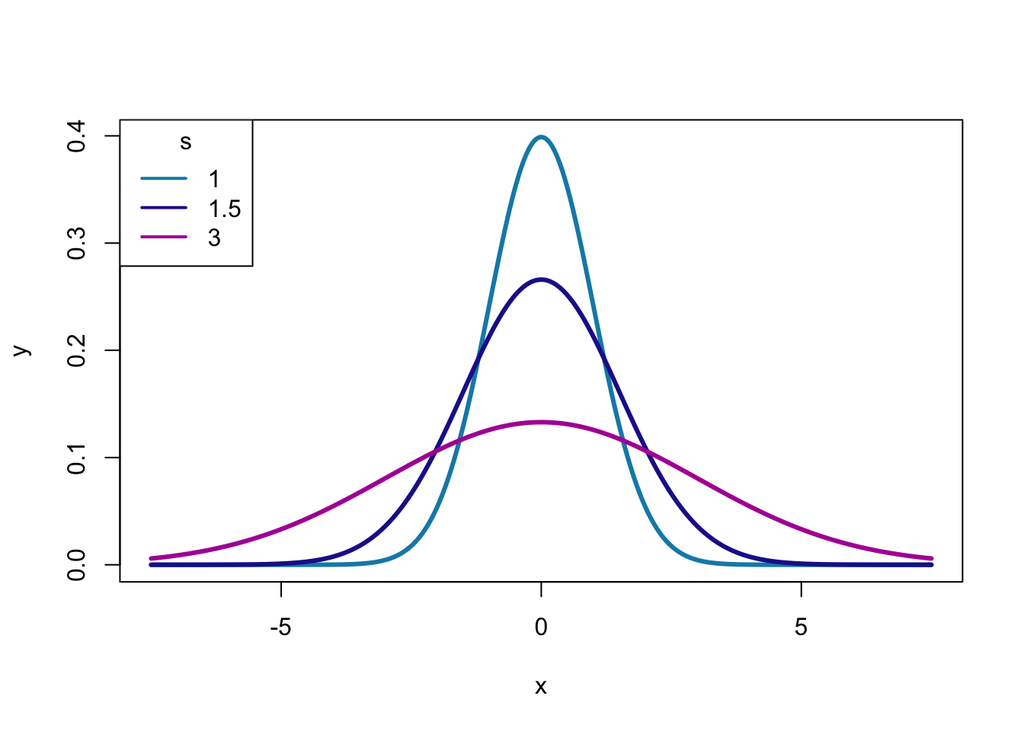

```r
x <- seq(-7.5, 7.5, 0.05)
cols <- c("#118ab6", "#212198", "#af13a4")
plot(x, dnorm(x, 0, 1), type = "l", xlab = "x", ylab = "y", col = cols[1], lwd = 3)
lines(x, dnorm(x, 0, 1.5), col = cols[2], lwd = 3)
lines(x, dnorm(x, 0, 3), col = cols[3], lwd = 3)
legend("topleft", legend = c(1, 1.5, 3), col = cols, lwd = 2, title = "s")
```

- $p(r_{i} | s)$ は $r_{i}$ の「出現しやすさ」を表している
  - $r_{i}$ が0に近い: ありがち
  - $|r_{i}|$ が大きい: あまりない
- 標準偏差$s$ は「集団内の $r_{i}$ のばらつき」を表している
  - $s$ が大きい: 個体差の大きい集団(過分散がひどい)

## 固定効果とランダム効果: 線形予測子の構成要素

- GLMMは以下の効果を「混合(mix)」した混合(効果)モデル(mixed effects model)
  - **固定効果(fixed effects)** : $\beta_{1}, \beta_{2} x_{i}$
    - データのかなり広い範囲を説明する大域的なパラメータ
    - $r_{i}$ のばらつき $s$ は(最尤推定される)固定効果
  - **ランダム効果(random effects)** : $r_{i}$
    - データのごく一部だけ担当している局所的なパラメータ

## 一般化線形混合モデルの最尤推定

- **$r_{i}$ は最尤推定できない**
  - 100個体分の生存数データ $y_{i}$ を説明するために100個のパラメータ $\{{\hat {r_{i}}}\}$ を最尤推定する: フルモデルになってしまう
- => *個体ごとの尤度 $L_{i}$ の式の中で $r_{i}$ を積分してしまう*

$$L_{i} = \int_{-\infty}^{\infty} p(y_{i} | \beta_{1}, \beta_{2}, r_{i}) p(r_{i} | s) dr_{i}$$

- 尤度の期待値 $E(L)$ を算出しているのに相当
  - 二項分布 $p(y_{i} | \beta_{1}, \beta_{2}, r_{i})$ と正規分布 $p(r_{i} | s)$ をかけて $r_{i}$ で積分する = **2種類の分布を混ぜ合わせている: 無限混合分布(infinite mixture distribution)**
  - c.f.) ポアソン分布と正規分布を混ぜることもできる
- => $r_{i}$ が消えた対数尤度 $\log L(\beta_{1}, \beta_{2}, s) = \log \prod_{i} L_{i}$ を最大にするような, パラメータ $\beta_{1}, \beta_{2}, s$ の最尤推定値を探す

### RでのGLMMの最尤推定

- `glmmML` packageを使用する
  - `cluster = id`: $r_{i}$ が「個体ごとに異なる独立なパラメータ」であることを指定
    - `d` 内の `id` 列に格納されている個体番号を使う

```r
library(glmmML)
fit.glmm <- glmmML(cbind(y, N - y) ~ x, data = d, family = binomial, cluster = id)
print(fit.glmm)
```

```
Call:  glmmML(formula = cbind(y, N - y) ~ x, family = binomial, data = d,      cluster = id)

              coef se(coef)      z Pr(>|z|)
(Intercept) -4.190   0.8777 -4.774 1.81e-06
x            1.005   0.2075  4.843 1.28e-06

Scale parameter in mixing distribution:  2.408 gaussian
Std. Error:                              0.2202

        LR p-value for H_0: sigma = 0:  2.136e-55

Residual deviance: 269.4 on 97 degrees of freedom   AIC: 275.4
```

- `coef`: パラメータの最尤推定値 (`se(coef)` や `z` は近似標準誤差やWaldのz値など)
  - ${\hat \beta_{1}}$: -4(真の値) vs. -4.1899008(推定値)
  - ${\hat \beta_{2}}$: 1(真の値) vs. 1.0048429(推定値)
- `Scale parameter ...`: $r_{i}$ のばらつき $s$ の最尤推定値
  - ${\hat s}$: 3(真の値) vs. 2.4081844
  - `Std. Error`: $s$ の推定値のばらつき(標準誤差)
- `Residual deviance ...`
  - `97 degrees`: 最尤推定をしたパラメータ数は $\beta_{1}, \beta_{2}, s$ の3つなので, 自由度は $100 - 3 = 97$ となる

GLMMから得られた予測結果を以下に図示する. $q_{i}$ の $x_{i}$ 依存性, 生存種子数 $y_{i}$ の分布が改善されている.

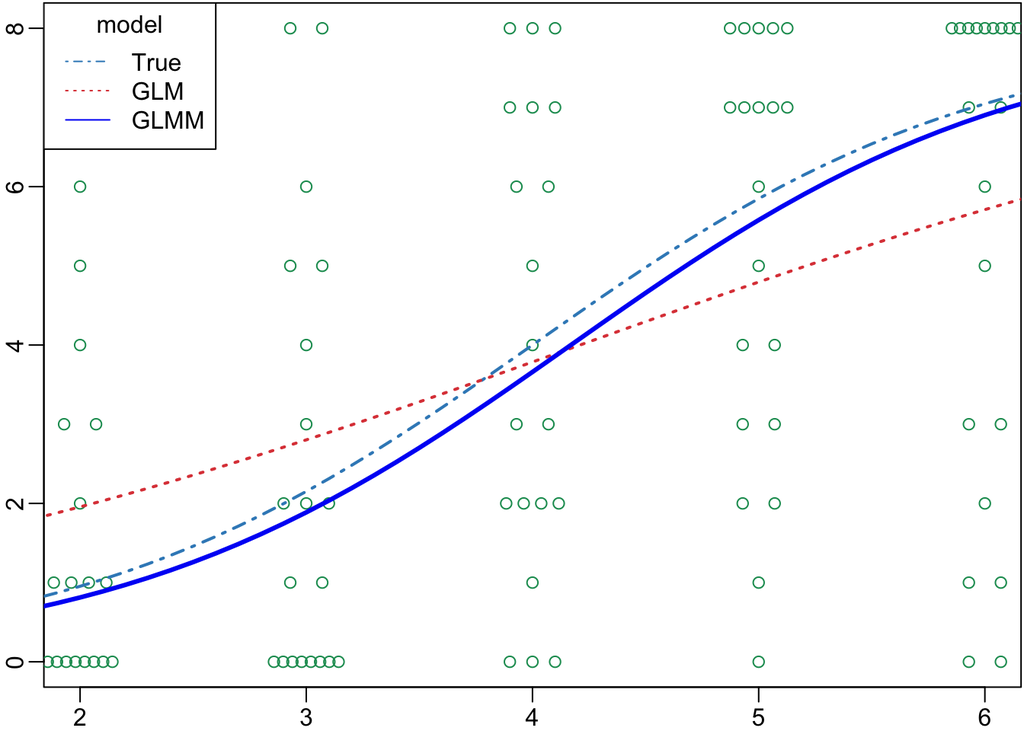

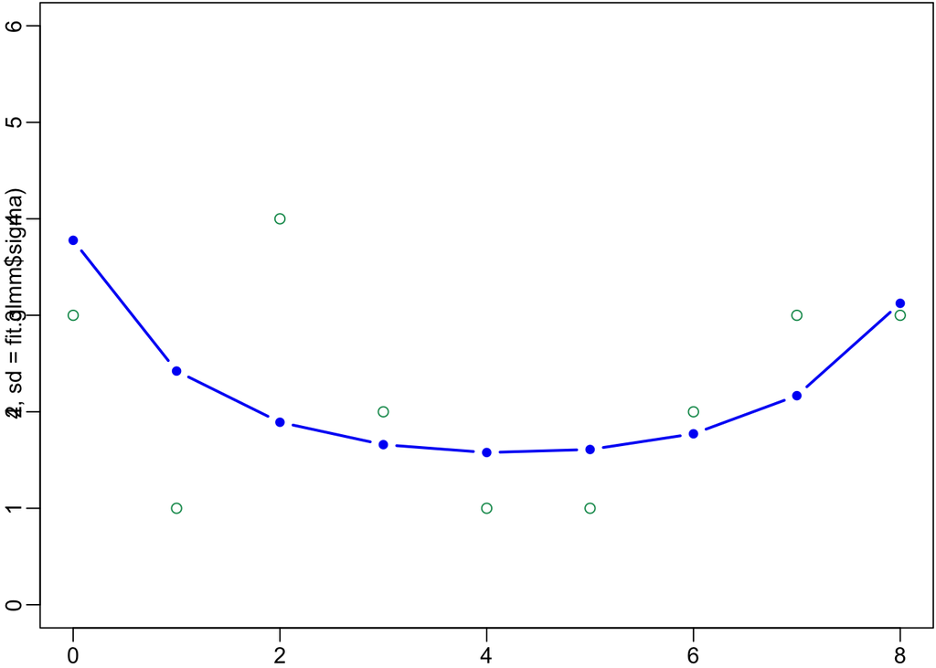

```r
beta.glmm <- fit.glmm$coefficients
col.glmm <- "#0205f5"

par.glmm()
plot.d(d)
line.true(col = )
lines(xx, logistic(beta.glm[1] + beta.glm[2] * xx) * max(v.x), lwd = 2, lty = 3, col = col.glm)
lines(xx, logistic(beta.glmm[1] + beta.glmm[2] * xx) * max(v.x), lwd = 3, col = col.glmm)
legend("topleft", legend = c("True", "GLM", "GLMM"), lty = c(4, 3, 1), col = c(col.true, col.glm, col.glmm), title = "model")

f.gaussian.binom <- function(alpha, x, size, fixed, sd)
    dbinom(x, size, logistic(fixed + alpha)) * dnorm(alpha, 0, sd)
d.gaussian.binom <- function(v.x, size, fixed, sd) sapply(
        v.x, function(x) integrate(
                f = f.gaussian.binom,
                lower = -sd * 10,
                upper = sd * 10,
                # for f.gaussian.binom
                x = x,
                size = size,
                fixed = fixed,
                sd = sd
        )$value
    )
par.glmm()
plot(
    v.x,
    nrow(d4) * d.gaussian.binom(
        v.x, 8,
        fixed = beta.glmm[1] + beta.glmm[2] * 4,
        sd = fit.glmm$sigma
    ),
    type = "b",
    ylim = c(0, 6),
    pch = 20, lwd = 2, col = col.glmm
)
points(v.x, table(factor(d4$y, levels = v.x)), pch = 1, col = "#199a60")
```

# どのようなときにGLMMが必要か

- GLMMを採用するかどうかの判断ポイント
  - 過分散の有無
  - **データのとり方から, 「個体差や場所差が識別できるかどうか」**
    - **反復** か **擬似反復** か

## 反復・擬似反復と統計モデルの関係

- **反復(replication)**: 個体差や場所差のばらつきを考慮しないデータのとり方
  - e.g.) 各個体で1つだけ種子の生死を調べる(個体差なし) / 1つの植木鉢に1つの個体だけ植える(場所差なし)
  - GLMで推定して問題ない
    - 個体差や場所差の効果を除去して, 統計モデルを簡単にできる
- **擬似反復(pseudo replication)**: 「それぞれの個体や場所から複数のデータをとる」
  - e.g.1) 別々の植木鉢に植えられた, それぞれの個体から採取した $N$ 個の種子の生死を調べた(個体差あり)
    - 個体差 $r_{i}$ を組み込んだGLMM: ${\rm logit}(q_{i}) = \beta_{1} + \beta_{2} + r_{i}$
  - e.g.2) 1つの植木鉢に複数の個体を植えて, それぞれの個体で1つだけ種子の生死を調べる(場所差あり)
    - 場所差 $r_{j}$ を組み込んだGLMM: ${\rm logit}(q_{i}) = \beta_{1} + \beta_{2} + r_{j}$
  - e.g.3) 1つの植木鉢に複数の個体を植えて, それぞれの個体から採取した $N$ 個の種子の生死を調べる(個体差, 場所差あり)
    - 個体差 $r_{i}$ と場所差 $r_{j}$ を組み込む: ${\rm logit}(q_{i}) = \beta_{1} + \beta_{2} + r_{i} + r_{j}$
      - GLMMと最尤推定では厳しい: 階層ベイズモデルとMCMC

### いろいろな分布のGLMM

- ポアソン分布 $\times$ 正規分布 のGLMM: `glmmML`
- ポアソン分布 $\times$ ガンマ分布 のGLMM: `MASS::glm.nb`
  - **負の二項分布(negative binomial distribution)**: ポアソン分布とガンマ分布の無限混合分布
    - ポアソン分布: $p(y | \lambda)$
    - $\lambda \sim$ ガンマ分布
- 応答変数のばらつきが正規分布, ガンマ分布であるときは, 過分散を定義することはできない
  - => サンプリングが擬似反復ならば, GLMMのような個体差・場所差を考慮したモデルが必要
  - 正規分布やガンマ分布のGLMM: `lme4::glmer`